# Accessibility by and to transit; comparison with transit Supply Index results

James Reynolds

2025-07-09

# Introduction

transit Supply Index (SI) has been previous developed (Currie and Senbergs 2007),

Currie, Graham, and Zed Senbergs. 2007. “Identifying spatial gaps in public transport provision for socially disadvantaged Australians: the Melbourne needs-gap study.” Australasian Transport Research Forum.

Previous development of code to calculate SI scores from GTFS datasets as an R package (Reynolds 2024).

Reynolds, James. 2024. “Gtfssupplyindex.” https://github.com/James-Reynolds/gtfssupplyindex.

# Research context

## The Suppy Index

$$\begin{equation}
SI_{area, time} = \sum{\frac{Area_{Bn}}{Area_{area}}*SL_{n, time}}
\end{equation}$$

The Supply Index (SI) equation is shown in the margin figure, in which: (1) $SI_{area, time}$ is the Supply Index for the area of interest and a given period of time; (2) $Area_{Bn}$ is the buffer area for each stop (n) within the area of interest. In Currie and Senbergs (2007) this was based on a radius of 400 metres for bus and tram stops, and 800 metres for railway stations; (3) $Area_{area}$ is the area of the area of interest; and (4) $SL_{n,time}$ is the number of transit arrivals for each stop for a given time period.

Minor adjustments have been made to generalise the equation, as Currie and Senbergs (2007) focus was the context of Melbourne’s Census Collection Districts (CCD) and calculations based on a week of transit service. CCDs predate the introduction of Statistical Areas 1, 2, 3, and 4 (SA1, SA2, SA3, SA4), and other geographical divisions currently used by the Australian Bureau of Statistics (ABS), which may be more familiar to readers.

# Methodology

R (R Core Team 2024), a widely used and readily available statistical programming language, was adopted for code development. The package development setup and workflow described by Wickham and Bryan (2023) was adopted in this study.

R Core Team. 2024. *R: A Language and Environment for Statistical Computing*. Vienna, Austria: R Foundation for Statistical Computing. https://www.R-project.org/.

Wickham, Hadley, and Jennifer Bryan. 2023. *R Packages*. " O’Reilly Media, Inc.". https://r-pkgs.org/.

Various existing packages were relied upon including: the sf package (Pebesma 2024) for geospatial analysis; the tidyverse (Wickham et al. 2019); gtfstools (Herszenhut et al. 2025); and tidytransit (Poletti et al. 2024). Some code was adapted from the tidytransit, gtfstools and other package’s examples, vignettes and other documentation. Tidytransit is licensed under GPL-2 | GPL-3, while gtfstools is lincensed under the more permissive MIT license. For simplicity, the gtfssupplyindex package developed here is licensed under GPL-3 so as to match tidytransit.

Pebesma, Edzer. 2024. *Sf: Simple Features for r*. https://r-spatial.github.io/sf/.

Wickham, Hadley, Mara Averick, Jennifer Bryan, Winston Chang, Lucy D’Agostino McGowan, Romain François, Garrett Grolemund, et al. 2019. “Welcome to the tidyverse.” *Journal of Open Source Software* 4 (43): 1686. https://doi.org/10.21105/joss.01686.

Herszenhut, Daniel, Rafael H. M. Pereira, Pedro R. Andrade, and Joao Bazzo. 2025. *Gtfstools: General Transit Feed Specification (GTFS) Editing and Analysing Tools*. https://ipeagit.github.io/gtfstools/.

Poletti, Flavio, Daniel Herszenhut, Mark Padgham, Tom Buckley, and Danton Noriega-Goodwin. 2024. *Tidytransit: Read, Validate, Analyze, and Map GTFS Feeds*. https://github.com/r-transit/tidytransit.

## Cases

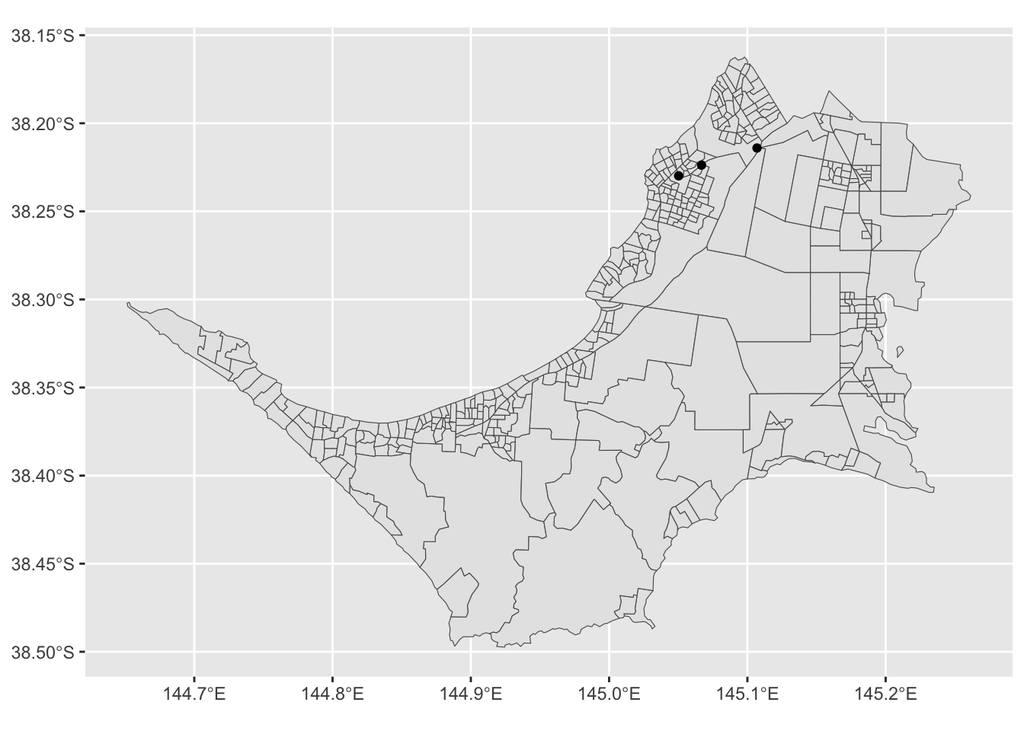

Mornington Penninsula SA1 zones and location of Mornington Tourist Rail stops.

Code development was undertaken using a number of cases for testing purposes, being: the Mornington Penninsula Tourist Railway, and Melbourne.

The Morning Penninsula Tourist Railway runs on Sundays and Wednesdays between Moorooduc and Mornington, with an intermediate stop at Tanti Park. A GTFS feed from 2018 was selected. ABS data was also used, primarily through the strayr and absmapsdata packages (Mackey et al. 2023). The Mornington Peninsular SA3 zone and the SA1 zones contained within were adopted as the areas_of_interest.

https://transitfeeds.com/p/mornington-railway/806/latest/stops

Mackey, Will, Matt Johnson, David Diviny, Matt Cowgill, Bryce Roney, William Lai, and Benjamin Wee. 2023. “Strayr.” https://runapp-aus.github.io/strayr/.

Larger scale testing was performed using the Victorian GTFS feed, published by Public Transport Victoria (PTV), sourced via Transit Mobility Data, (2023) for historical feeds. Again, ABS data was used for the areas_of_interest.

Transit Mobility Data,. 2023. “PTV GTFS - OpenMobilityData.” 2023. https://transitfeeds.com/p/ptv/497.

# Discussion and conclusions